# tourism

```python
from scipy import stats
import pandas as pd
import numpy as np
import os
import seaborn as sns
import matplotlib.pyplot as plt
from sklearn.metrics import mean_squared_error, r2_score, mean_absolute_error
from sklearn.model_selection import GridSearchCV,train_test_split
from sklearn.linear_model import LogisticRegression
from mlxtend.plotting import plot_sequential_feature_selection as plot_sfs
from mlxtend.feature_selection import SequentialFeatureSelector as SFS
from uszipcode import SearchEngine
from functools import lru_cache
from sklearn.metrics import (
    make_scorer,
    f1_score,
    accuracy_score,
    recall_score,
    precision_score,
    confusion_matrix,
    roc_auc_score,
   precision_recall_curve,
    roc_curve,
)
from sklearn.tree import DecisionTreeClassifier
from sklearn.ensemble import (BaggingClassifier,
                             RandomForestClassifier,
                             AdaBoostClassifier,
                             GradientBoostingClassifier,
                             StackingClassifier)
from sklearn import metrics
from xgboost import XGBClassifier


sns.set(color_codes=True) # adds a nice background to the graphs

DEFAULT_CLASSIFICATION_THRESHOLD = 0.5
DEFAULT_SHEET_NAME = "Tourism"
```

```python
def load_dataframe_from_xlsx(xlsx_file_name:str)->pd.DataFrame:
    """Load a xlsx file and return a pandas dataframe.

    Parameters
    ----------
    xlsx_file_name : str
        The csv file

    Return
    ------
    data_frame : DataFrame
        Pandas data frame

    Raises
    ------
    AssertionError
        If the file type is not of type csv
    """

    file_name = str(xlsx_file_name)
    _,file_type=os.path.splitext(file_name)
    assert file_type == '.xlsx',f"File format should be of type xlsx instead of format {file_type}"

    data_frame = pd.read_excel(io=xlsx_file_name,sheet_name=DEFAULT_SHEET_NAME)
    return data_frame

def print_frame_meta_info(data_frame:pd.DataFrame):
    """Load a data frame file and print meta info of the data frame.

    Parameters
    ----------
    data_frame : DataFrame
    """
    rows,columns = np.shape(data_frame)
    print(f"Shape of the data frame is: {rows},{columns}")
    print(f"Number of variables are: {columns}")
    print("Memory Usage:"+str(data_frame.memory_usage(index=False,deep=True).sum()*0.001))
    print("")
    print("")


    for column in data_frame.columns:
        print(f"Name of the column: {column}")
        data_in_column = data_frame[column]
        unique_values = np.unique(data_in_column)
        print("Memory Usage:"+str(data_in_column.memory_usage()*0.001))
        print(f"Number of unique values:{len(unique_values)}")
        print(f"The unique values:{unique_values}")
        print("")


def fix_gender(gender:str)->str:
    """Take in a gender and return the right gender without typo

    Parameters
    ----------
    gender : gender


    Return
    ------
    gender : Name of the gender
    """
    return gender if gender in ["Male","Female"] else "Female"




def print_model_performance_for_classification(model,
                                               features,
                                               target,
                                               threshold=DEFAULT_CLASSIFICATION_THRESHOLD):
    """
    Print the relevant scores for a classification model

    model: the model to classify with
    features: the feature vectors
    target: our target variable to predict
    threshold: threshold to infer as belonging to lable 1.
    """
    # predicting using the independent variables
    prediction = model.predict_proba(features)[:, 1]
    prediction_threshold = prediction > threshold
    final_prediction = np.round(prediction_threshold)
    # get the scores
    accuracy = accuracy_score(target, final_prediction)
    recall = recall_score(target, final_prediction)
    precision = precision_score(target, final_prediction)
    f1 = f1_score(target, final_prediction)

    print(f"Accuracy:{accuracy}")
    print(f"Recall:{recall}")
    print(f"Precision: {precision}")
    print(f"F1 score: {f1}")



def tune_model(model,
               parameters,
               X_train:pd.core.frame.DataFrame,
               y_train:pd.core.series.Series,):
    """Takes in model and parameters and return the tuned model.

    Parameters
    ----------
    model : any classifier
    parameters : the parameters


    Return
    ------
    prunned_tree : prunned_tree with the tuned parameters
    """

    # we care about the recall score more, hence setting that
    acc_scorer = make_scorer(metrics.recall_score)

    # Run the grid search
    grid_obj = GridSearchCV(model, parameters, scoring=acc_scorer,cv=5)
    grid_obj = grid_obj.fit(X_train, y_train)

    # get the tuned model
    estimator_tuned = grid_obj.best_estimator_

    # Fir the data to the tuned model
    estimator_tuned.fit(X_train, y_train)

    return estimator_tuned


def box_plot_num_columns(columns):
    """For the provided columns do a box plot.

    Parameters
    ----------
    columns : column names
    """
    plt.figure(figsize=(20, 30))

    for idx, variable in enumerate(columns):
        plt.subplot(5, 5, idx + 1)
        sns.boxplot(data=data[variable])
        plt.tight_layout()
        plt.title(variable)

    plt.show()

def treat_outliers(df, col):
    """
    Treats outliers in a variable

    df: dataframe
    col: dataframe column
    """
    Q1 = df[col].quantile(0.25)
    Q3 = df[col].quantile(0.75)
    IQR = Q3 - Q1
    Lower_Whisker = Q1 - 1.5 * IQR
    Upper_Whisker = Q3 + 1.5 * IQR


    df[col] = np.clip(df[col], Lower_Whisker, Upper_Whisker)

    return df


def treat_all_outliers(df, num_cols):
    """
    Treat outliers in a list of variables

    df: dataframe
    col_list: list of dataframe columns
    """
    for c in num_cols:
        df = treat_outliers(df, c)
    return df


def get_metrics_score(model,
                      X_train,
                      X_test,
                      y_train,
                      y_test):
    '''
    Return all the metrics score of a model on training/testing

    Parameters
    ----------
    model : classifier to predict values of X

    '''

    scores=[]

    #Predict on train and tests
    pred_train = model.predict(X_train)
    pred_test = model.predict(X_test)

    #Accuracy of the model
    train_acc = model.score(X_train,y_train)
    test_acc = model.score(X_test,y_test)

    #Recall of the model
    train_recall = metrics.recall_score(y_train,pred_train)
    test_recall = metrics.recall_score(y_test,pred_test)

    #Precision of the model
    train_precision = metrics.precision_score(y_train,pred_train)
    test_precision = metrics.precision_score(y_test,pred_test)

    scores.extend((train_acc,test_acc,train_recall,test_recall,train_precision,test_precision))


    return scores
```

```python
# load the dataset
raw_data = load_dataframe_from_xlsx("Tourism.xlsx")
# create a copy, where we can work with for the analysis
data = raw_data.copy(deep=True)
```

```python
# Serial number indexing is exactly same as the pandas indexig (see above) and also not needed for the analysis, hence dropping it.
data.drop(['CustomerID'],axis=1,inplace=True)
```

```python
# Let's see if the dataset has any missing value
data.isnull().sum().sort_values(ascending=False)
```

```
DurationOfPitch             251
MonthlyIncome               233
Age                         226
NumberOfTrips               140
NumberOfChildrenVisiting     66
NumberOfFollowups            45
PreferredPropertyStar        26
TypeofContact                25
Gender                        0
CityTier                      0
Occupation                    0
ProductPitched                0
NumberOfPersonVisiting        0
Designation                   0
MaritalStatus                 0
Passport                      0
PitchSatisfactionScore        0
OwnCar                        0
ProdTaken                     0
dtype: int64
```

# Missing value treatment

As seen above, some of the columns have missing values. For certain columns (which has continous variable), the missing value will be replaced by the median. For other types, the mode will be replacing the missing value. This is done below.

```python
data["DurationOfPitch"].fillna(data["DurationOfPitch"].median(), inplace=True)
data["MonthlyIncome"].fillna(data["MonthlyIncome"].median(), inplace=True)
data["NumberOfTrips"].fillna(data["NumberOfTrips"].median(), inplace=True)
data["NumberOfChildrenVisiting"].fillna(data["NumberOfChildrenVisiting"].mode()[0], inplace=True)
data["NumberOfFollowups"].fillna(data["NumberOfFollowups"].median(), inplace=True)
data["PreferredPropertyStar"].fillna(data["PreferredPropertyStar"].mode()[0], inplace=True)
data["TypeofContact"].fillna(data["TypeofContact"].mode()[0], inplace=True)
data["Age"].fillna(data["Age"].median(), inplace=True)
```

# Inspect the meta of the dataset

```python
print_frame_meta_info(data)
```

```
Shape of the data frame is: 4888,19
Number of variables are: 19
Memory Usage:2427.582


Name of the column: ProdTaken
Memory Usage:39.232
Number of unique values:2
The unique values:[0 1]

Name of the column: Age
Memory Usage:39.232
Number of unique values:44
The unique values:[18. 19. 20. 21. 22. 23. 24. 25. 26. 27. 28. 29. 30. 31. 32. 33. 34. 35.
 36. 37. 38. 39. 40. 41. 42. 43. 44. 45. 46. 47. 48. 49. 50. 51. 52. 53.
 54. 55. 56. 57. 58. 59. 60. 61.]

Name of the column: TypeofContact
Memory Usage:39.232
Number of unique values:2
The unique values:['Company Invited' 'Self Enquiry']

Name of the column: CityTier
Memory Usage:39.232
Number of unique values:3
The unique values:[1 2 3]

Name of the column: DurationOfPitch
Memory Usage:39.232
Number of unique values:34
The unique values:[  5.   6.   7.   8.   9.  10.  11.  12.  13.  14.  15.  16.  17.  18.
  19.  20.  21.  22.  23.  24.  25.  26.  27.  28.  29.  30.  31.  32.
  33.  34.  35.  36. 126. 127.]

Name of the column: Occupation
Memory Usage:39.232
Number of unique values:4
The unique values:['Free Lancer' 'Large Business' 'Salaried' 'Small Business']

Name of the column: Gender
```

[output cut: 48 more lines]

```

Name of the column: NumberOfChildrenVisiting
Memory Usage:39.232
Number of unique values:4
The unique values:[0. 1. 2. 3.]

Name of the column: Designation
Memory Usage:39.232
Number of unique values:5
The unique values:['AVP' 'Executive' 'Manager' 'Senior Manager' 'VP']

Name of the column: MonthlyIncome
Memory Usage:39.232
Number of unique values:2475
The unique values:[ 1000.  4678. 16009. ... 38677. 95000. 98678.]
```

# Fixing the Gender column

1. As seen above, one of the unique values of the gender column are "Fe Male".
2. This is a typo for sure and it needs to be fixed and it is done below.

```python
# Fixing the gender
data["Gender"] = data["Gender"].apply(lambda x: fix_gender(gender=x))
```

```python
data.head()
```

|  | ProdTaken | Age | TypeofContact | CityTier | DurationOfPitch | Occupation | Gender | NumberOfPersonVisiting | NumberOfFollowups | ProductPitched | PreferredPropertyStar | MaritalStatus | NumberOfTrips | Passport | PitchSatisfactionScore | OwnCar | NumberOfChildrenVisiting | Designation | MonthlyIncome |
| --- | --- | --- | --- | --- | --- | --- | --- | --- | --- | --- | --- | --- | --- | --- | --- | --- | --- | --- | --- |
| 0 | 1 | 41.0 | Self Enquiry | 3 | 6.0 | Salaried | Female | 3 | 3.0 | Deluxe | 3.0 | Single | 1.0 | 1 | 2 | 1 | 0.0 | Manager | 20993.0 |
| 1 | 0 | 49.0 | Company Invited | 1 | 14.0 | Salaried | Male | 3 | 4.0 | Deluxe | 4.0 | Divorced | 2.0 | 0 | 3 | 1 | 2.0 | Manager | 20130.0 |
| 2 | 1 | 37.0 | Self Enquiry | 1 | 8.0 | Free Lancer | Male | 3 | 4.0 | Basic | 3.0 | Single | 7.0 | 1 | 3 | 0 | 0.0 | Executive | 17090.0 |
| 3 | 0 | 33.0 | Company Invited | 1 | 9.0 | Salaried | Female | 2 | 3.0 | Basic | 3.0 | Divorced | 2.0 | 1 | 5 | 1 | 1.0 | Executive | 17909.0 |
| 4 | 0 | 36.0 | Self Enquiry | 1 | 8.0 | Small Business | Male | 2 | 3.0 | Basic | 4.0 | Divorced | 1.0 | 0 | 5 | 1 | 0.0 | Executive | 18468.0 |

# Univariate analysis

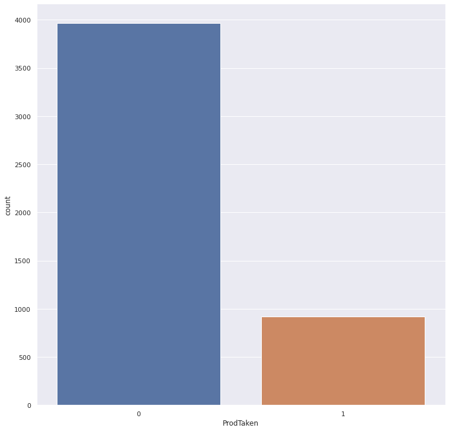

```
Number of customers with 1 ProdTaken: 920
Number of customers with 0 ProdTaken: 3968
```

```python
col_name = "ProdTaken"
fig, ax = plt.subplots()
fig.set_size_inches(10.7, 10.27)
ax = sns.countplot(x=col_name, data=data)
ax.set_xticklabels(ax.get_xticklabels())
plt.tight_layout()
plt.show()


for status in data[col_name].unique():
    print(f"Number of customers with {status} {col_name}: {len(data[(data.get(col_name) == status)])}")
```

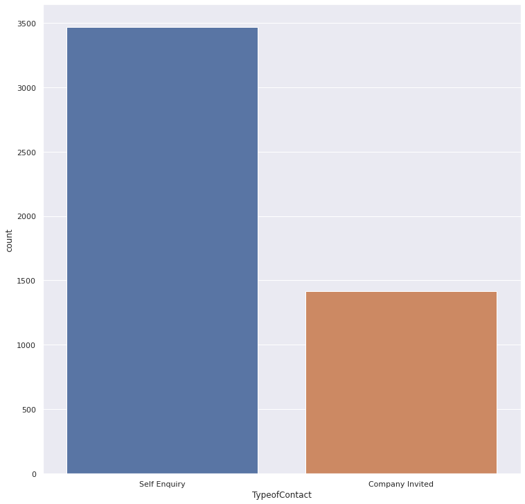

```
Number of customers with Self Enquiry TypeofContact: 3469
Number of customers with Company Invited TypeofContact: 1419
```

```python
col_name = "TypeofContact"
fig, ax = plt.subplots()
fig.set_size_inches(10.7, 10.27)
ax = sns.countplot(x=col_name, data=data)
ax.set_xticklabels(ax.get_xticklabels())
plt.tight_layout()
plt.show()


for status in data[col_name].unique():
    print(f"Number of customers with {status} {col_name}: {len(data[(data.get(col_name) == status)])}")
```

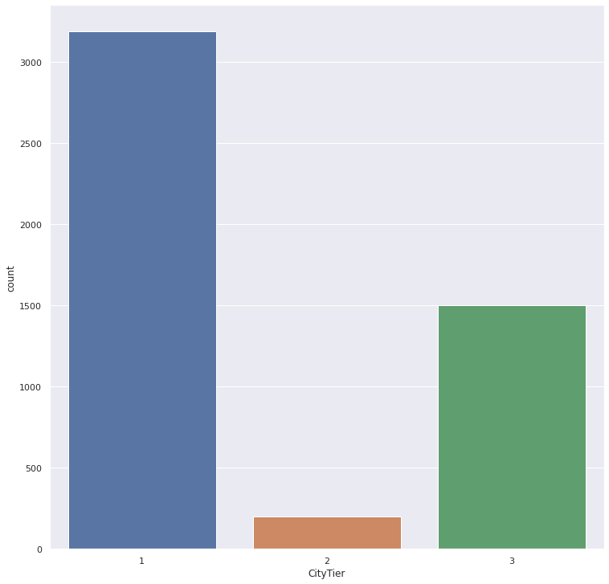

```
Number of customers with 3 CityTier: 1500
Number of customers with 1 CityTier: 3190
Number of customers with 2 CityTier: 198
```

```python
col_name = "CityTier"
fig, ax = plt.subplots()
fig.set_size_inches(10.7, 10.27)
ax = sns.countplot(x=col_name, data=data)
ax.set_xticklabels(ax.get_xticklabels())
plt.tight_layout()
plt.show()


for status in data[col_name].unique():
    print(f"Number of customers with {status} {col_name}: {len(data[(data.get(col_name) == status)])}")
```

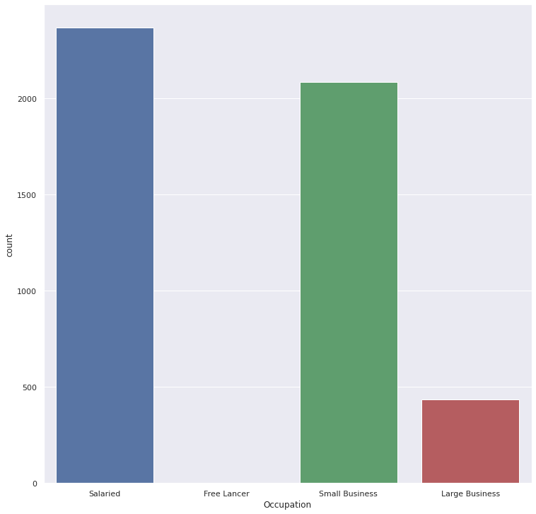

```
Number of customers with Salaried Occupation: 2368
Number of customers with Free Lancer Occupation: 2
Number of customers with Small Business Occupation: 2084
Number of customers with Large Business Occupation: 434
```

```python
col_name = "Occupation"
fig, ax = plt.subplots()
fig.set_size_inches(10.7, 10.27)
ax = sns.countplot(x=col_name, data=data)
ax.set_xticklabels(ax.get_xticklabels())
plt.tight_layout()
plt.show()


for status in data[col_name].unique():
    print(f"Number of customers with {status} {col_name}: {len(data[(data.get(col_name) == status)])}")
```

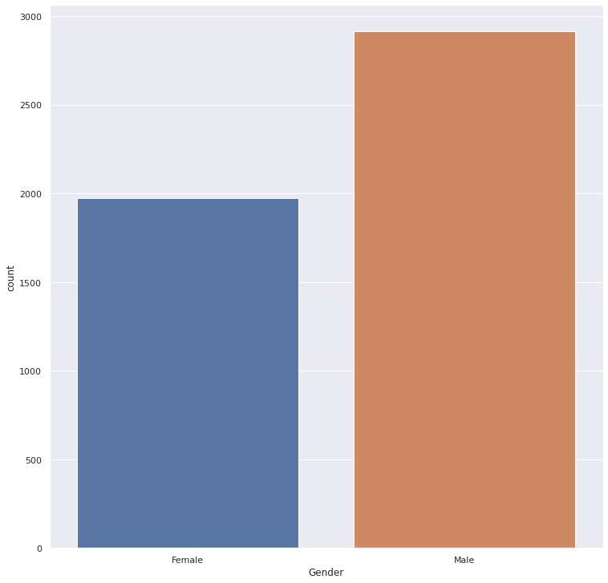

```
Number of customers with Female Gender: 1972
Number of customers with Male Gender: 2916
```

```python
col_name = "Gender"
fig, ax = plt.subplots()
fig.set_size_inches(10.7, 10.27)
ax = sns.countplot(x=col_name, data=data)
ax.set_xticklabels(ax.get_xticklabels())
plt.tight_layout()
plt.show()


for status in data[col_name].unique():
    print(f"Number of customers with {status} {col_name}: {len(data[(data.get(col_name) == status)])}")
```

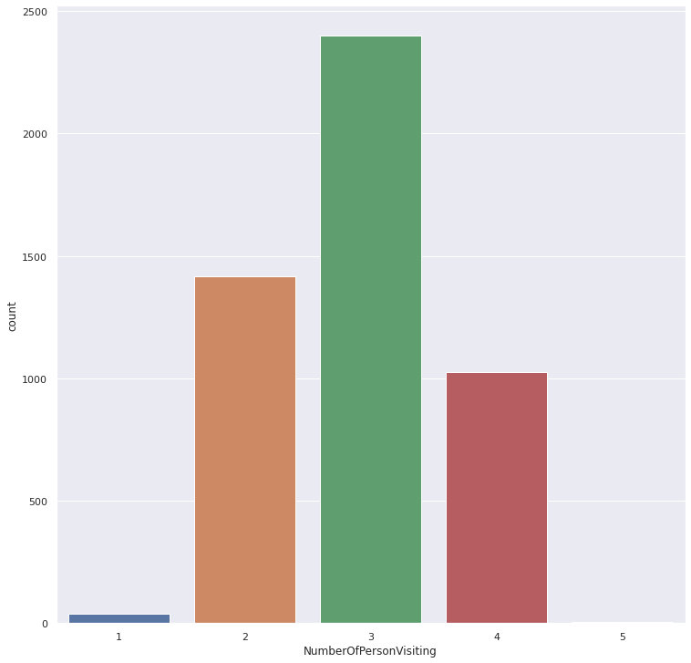

```
Number of customers with 3 NumberOfPersonVisiting: 2402
Number of customers with 2 NumberOfPersonVisiting: 1418
Number of customers with 1 NumberOfPersonVisiting: 39
Number of customers with 4 NumberOfPersonVisiting: 1026
Number of customers with 5 NumberOfPersonVisiting: 3
```

```python
col_name = "NumberOfPersonVisiting"
fig, ax = plt.subplots()
fig.set_size_inches(10.7, 10.27)
ax = sns.countplot(x=col_name, data=data)
ax.set_xticklabels(ax.get_xticklabels())
plt.tight_layout()
plt.show()


for status in data[col_name].unique():
    print(f"Number of customers with {status} {col_name}: {len(data[(data.get(col_name) == status)])}")
```

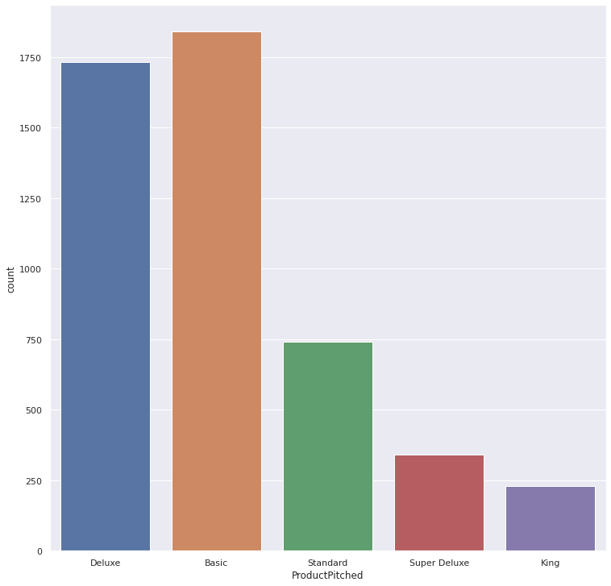

```
Number of products pitched with Deluxe : 1732
Number of products pitched with Basic : 1842
Number of products pitched with Standard : 742
Number of products pitched with Super Deluxe : 342
Number of products pitched with King : 230
```

```python
col_name = "ProductPitched"
fig, ax = plt.subplots()
fig.set_size_inches(10.7, 10.27)
ax = sns.countplot(x=col_name, data=data)
ax.set_xticklabels(ax.get_xticklabels())
plt.tight_layout()
plt.show()


for status in data[col_name].unique():
    print(f"Number of products pitched with {status} : {len(data[(data.get(col_name) == status)])}")
```

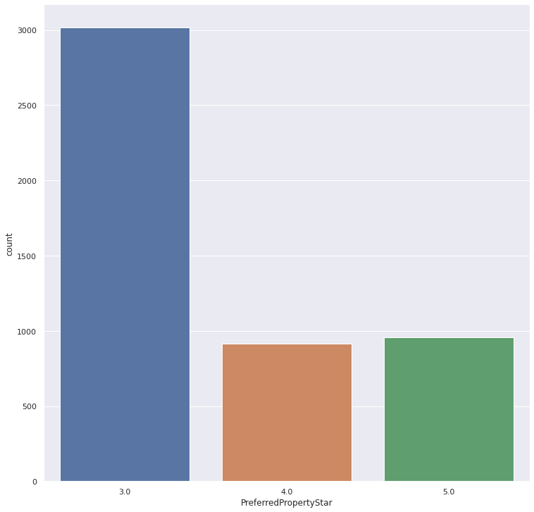

```
Number of customers rated with 3.0 PreferredPropertyStar: 3019
Number of customers rated with 4.0 PreferredPropertyStar: 913
Number of customers rated with 5.0 PreferredPropertyStar: 956
```

```python
col_name = "PreferredPropertyStar"
fig, ax = plt.subplots()
fig.set_size_inches(10.7, 10.27)
ax = sns.countplot(x=col_name, data=data)
ax.set_xticklabels(ax.get_xticklabels())
plt.tight_layout()
plt.show()


for status in data[col_name].unique():
    print(f"Number of customers rated with {status} {col_name}: {len(data[(data.get(col_name) == status)])}")
```

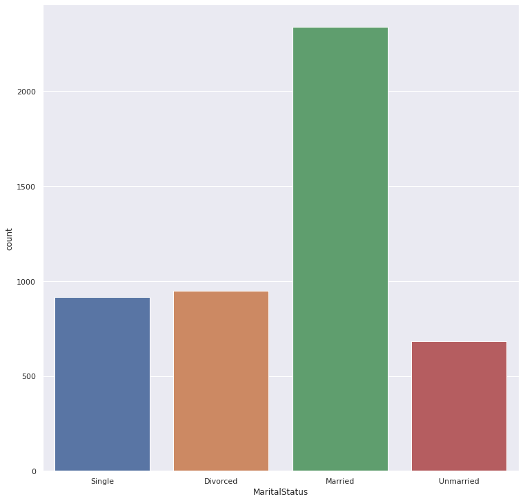

```
Number of customers with Single MaritalStatus: 916
Number of customers with Divorced MaritalStatus: 950
Number of customers with Married MaritalStatus: 2340
Number of customers with Unmarried MaritalStatus: 682
```

```python
col_name = "MaritalStatus"
fig, ax = plt.subplots()
fig.set_size_inches(10.7, 10.27)
ax = sns.countplot(x=col_name, data=data)
ax.set_xticklabels(ax.get_xticklabels())
plt.tight_layout()
plt.show()


for status in data[col_name].unique():
    print(f"Number of customers with {status} {col_name}: {len(data[(data.get(col_name) == status)])}")
```

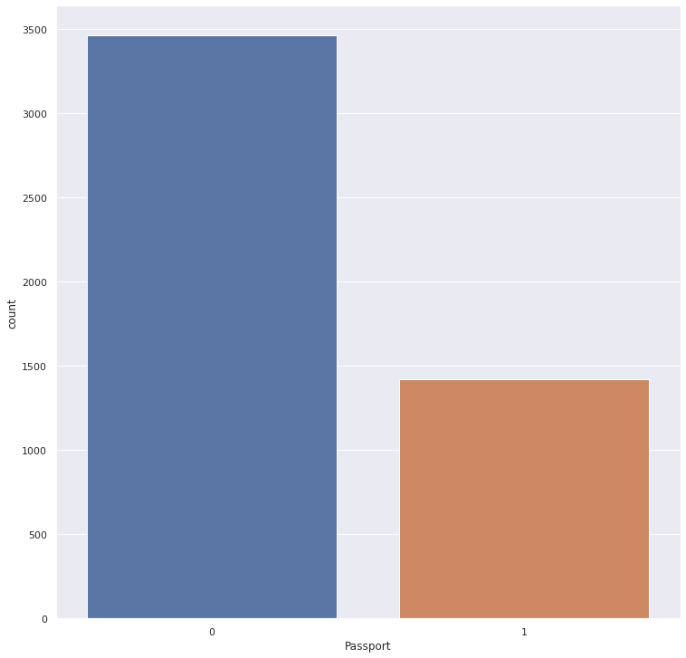

```
Number of customers with 1 Passport: 1422
Number of customers with 0 Passport: 3466
```

```python
col_name = "Passport"
fig, ax = plt.subplots()
fig.set_size_inches(10.7, 10.27)
ax = sns.countplot(x=col_name, data=data)
ax.set_xticklabels(ax.get_xticklabels())
plt.tight_layout()
plt.show()


for status in data[col_name].unique():
    print(f"Number of customers with {status} {col_name}: {len(data[(data.get(col_name) == status)])}")
```

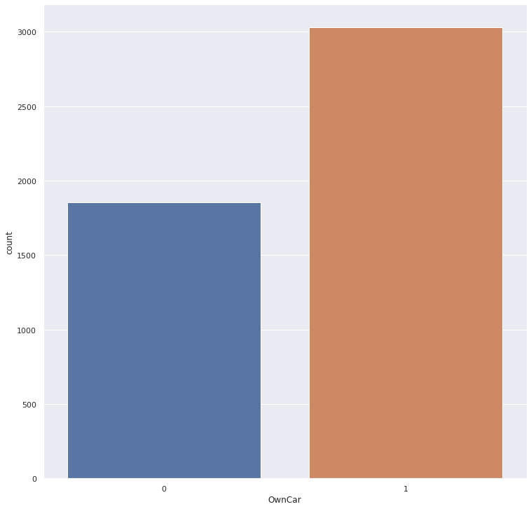

```
Number of customers with 1 OwnCar: 3032
Number of customers with 0 OwnCar: 1856
```

```python
col_name = "OwnCar"
fig, ax = plt.subplots()
fig.set_size_inches(10.7, 10.27)
ax = sns.countplot(x=col_name, data=data)
ax.set_xticklabels(ax.get_xticklabels())
plt.tight_layout()
plt.show()


for status in data[col_name].unique():
    print(f"Number of customers with {status} {col_name}: {len(data[(data.get(col_name) == status)])}")
```

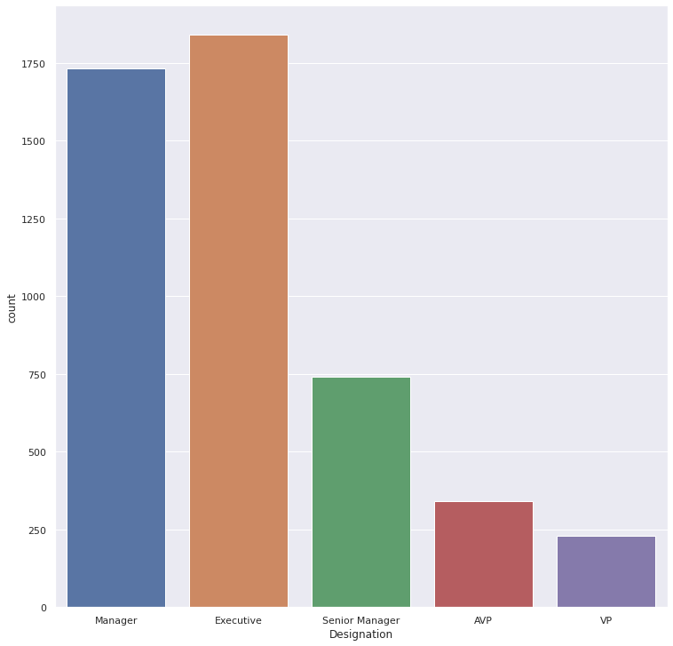

```
Number of customers with Manager Designation: 1732
Number of customers with Executive Designation: 1842
Number of customers with Senior Manager Designation: 742
Number of customers with AVP Designation: 342
Number of customers with VP Designation: 230
```

```python
col_name = "Designation"
fig, ax = plt.subplots()
fig.set_size_inches(10.7, 10.27)
ax = sns.countplot(x=col_name, data=data)
ax.set_xticklabels(ax.get_xticklabels())
plt.tight_layout()
plt.show()


for status in data[col_name].unique():
    print(f"Number of customers with {status} {col_name}: {len(data[(data.get(col_name) == status)])}")
```

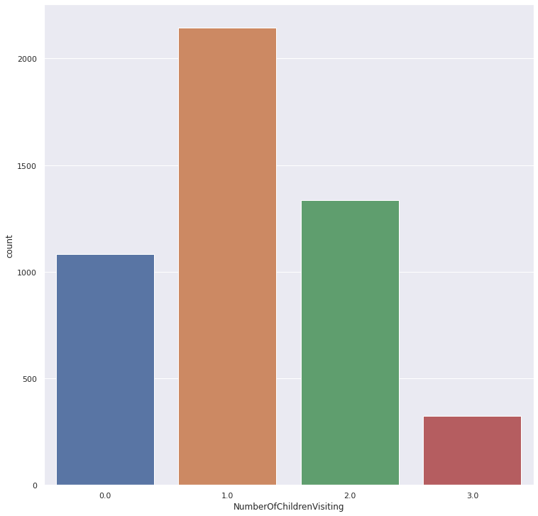

```
Number of customers with 0.0 NumberOfChildrenVisiting: 1082
Number of customers with 2.0 NumberOfChildrenVisiting: 1335
Number of customers with 1.0 NumberOfChildrenVisiting: 2146
Number of customers with 3.0 NumberOfChildrenVisiting: 325
```

```python
col_name = "NumberOfChildrenVisiting"
fig, ax = plt.subplots()
fig.set_size_inches(10.7, 10.27)
ax = sns.countplot(x=col_name, data=data)
ax.set_xticklabels(ax.get_xticklabels())
plt.tight_layout()
plt.show()


for status in data[col_name].unique():
    print(f"Number of customers with {status} {col_name}: {len(data[(data.get(col_name) == status)])}")
```

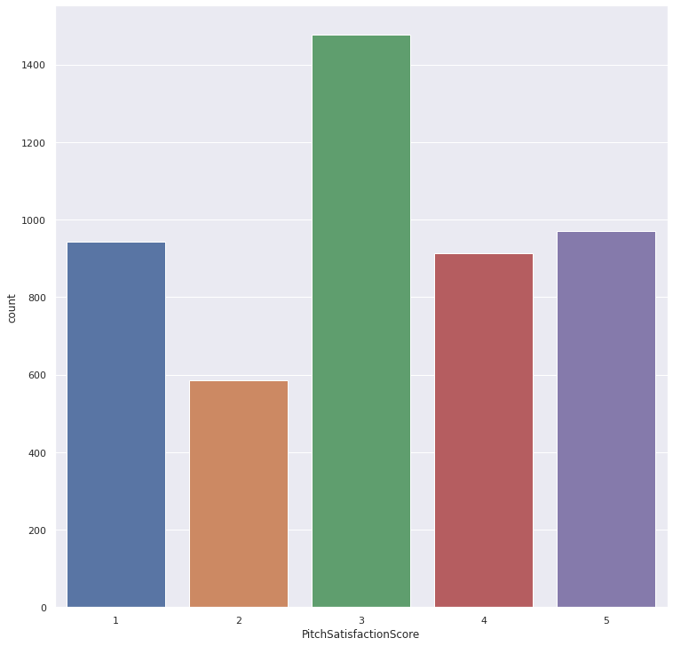

```
Number of customers rated 2 PitchSatisfactionScore: 586
Number of customers rated 3 PitchSatisfactionScore: 1478
Number of customers rated 5 PitchSatisfactionScore: 970
Number of customers rated 4 PitchSatisfactionScore: 912
Number of customers rated 1 PitchSatisfactionScore: 942
```

```python
col_name = "PitchSatisfactionScore"
fig, ax = plt.subplots()
fig.set_size_inches(10.7, 10.27)
ax = sns.countplot(x=col_name, data=data)
ax.set_xticklabels(ax.get_xticklabels())
plt.tight_layout()
plt.show()


for status in data[col_name].unique():
    print(f"Number of customers rated {status} {col_name}: {len(data[(data.get(col_name) == status)])}")
```

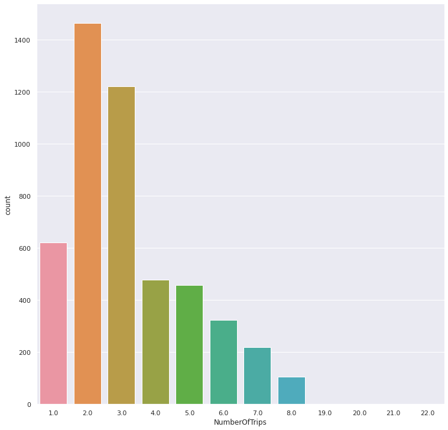

```
Number of customers who went for 1.0 NumberOfTrips: 620
Number of customers who went for 2.0 NumberOfTrips: 1464
Number of customers who went for 7.0 NumberOfTrips: 218
Number of customers who went for 5.0 NumberOfTrips: 458
Number of customers who went for 6.0 NumberOfTrips: 322
Number of customers who went for 3.0 NumberOfTrips: 1219
Number of customers who went for 4.0 NumberOfTrips: 478
Number of customers who went for 19.0 NumberOfTrips: 1
Number of customers who went for 21.0 NumberOfTrips: 1
Number of customers who went for 8.0 NumberOfTrips: 105
Number of customers who went for 20.0 NumberOfTrips: 1
Number of customers who went for 22.0 NumberOfTrips: 1
```

```python
col_name = "NumberOfTrips"
fig, ax = plt.subplots()
fig.set_size_inches(10.7, 10.27)
ax = sns.countplot(x=col_name, data=data)
ax.set_xticklabels(ax.get_xticklabels())
plt.tight_layout()
plt.show()


for status in data[col_name].unique():
    print(f"Number of customers who went for {status} {col_name}: {len(data[(data.get(col_name) == status)])}")
# note: customers who went for more than 19 trips is an outlier (since less count of them), need to be treated
```

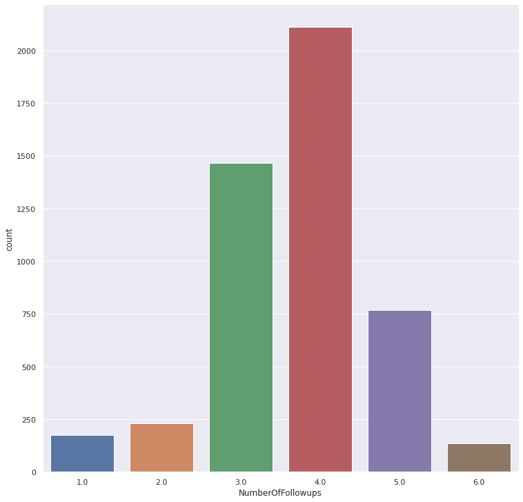

```
Number of 3.0 NumberOfFollowups: 1466
Number of 4.0 NumberOfFollowups: 2113
Number of 2.0 NumberOfFollowups: 229
Number of 5.0 NumberOfFollowups: 768
Number of 1.0 NumberOfFollowups: 176
Number of 6.0 NumberOfFollowups: 136
```

```python
col_name = "NumberOfFollowups"
fig, ax = plt.subplots()
fig.set_size_inches(10.7, 10.27)
ax = sns.countplot(x=col_name, data=data)
ax.set_xticklabels(ax.get_xticklabels())
plt.tight_layout()
plt.show()


for status in data[col_name].unique():
    print(f"Number of {status} {col_name}: {len(data[(data.get(col_name) == status)])}")
```

```
Univariate Analysis of Age
Max Age is 61.0
Min Age is 18.0
Mean Age is 37.54725859247136
```

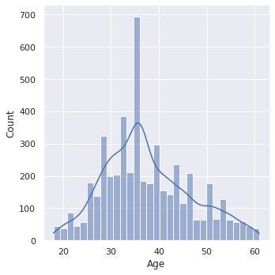

```python
col_name = "Age"
print(f"Univariate Analysis of {col_name}")
data_points = data.get(col_name)
sns.displot(data_points,kde=True);
print(f"Max {col_name} is {np.max(data_points)}")
print(f"Min {col_name} is {np.min(data_points)}")
print(f"Mean {col_name} is {np.mean(data_points)}")
```

```
Univariate Analysis of DurationOfPitch
Max DurationOfPitch is 127.0
Min DurationOfPitch is 5.0
Mean DurationOfPitch is 15.362929623567922
```

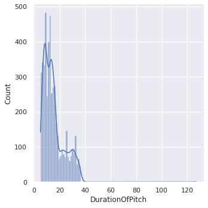

```python
col_name = "DurationOfPitch"
print(f"Univariate Analysis of {col_name}")
data_points = data.get(col_name)
sns.displot(data_points,kde=True);
print(f"Max {col_name} is {np.max(data_points)}")
print(f"Min {col_name} is {np.min(data_points)}")
print(f"Mean {col_name} is {np.mean(data_points)}")
# Note: Max outlier of 127 (going by minutes) does not make any sense. need to treat this later.
```

```
Univariate Analysis of MonthlyIncome
Max MonthlyIncome is 98678.0
Min MonthlyIncome is 1000.0
Mean MonthlyIncome is 23559.17941898527
```

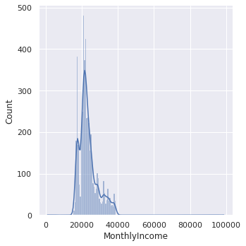

```python
col_name="MonthlyIncome"
print(f"Univariate Analysis of {col_name}")
data_points = data.get(col_name)
sns.displot(data_points,kde=True);
print(f"Max {col_name} is {np.max(data_points)}")
print(f"Min {col_name} is {np.min(data_points)}")
print(f"Mean {col_name} is {np.mean(data_points)}")
```

# BI VARIATE ANALYSIS

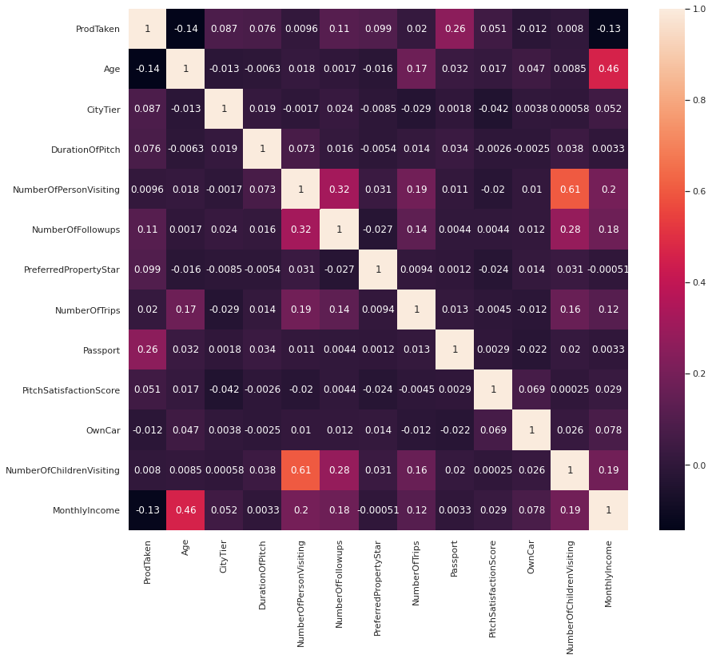

```python
# plot the correlation coefficients
fig, ax = plt.subplots(figsize=(14,12))
sns.heatmap(data.corr(), annot=True,ax=ax)
```

# Observations from the correlation matrix (above)

- Some decent +ve correlation between the customers who have taken the travel packages and also who has a passport.
- Strong +ve correlation between age and income (which makes sense).
- Slight -ve correlation between age and prodtaken. Meaning older people are not open to taking the package, compared to younger folks.
- good +ve correlation between number of person visiting and number of follow ups.
- As expected strong +ve correlation between number of person visiting and number of children visiting (as children are people too).
- good +ve correlation between number of follow ups and children visiting. May more calls from the company will prompt the customer to make a travel plan (considering their kids).
- Decent +ve correlation between number of trips and number of person visiting (as in a larger group, people give different ideas and come up with different travel plan).
- As expected decent +ve correlation between number of person visiting/number of children visiting and the monthly income.

## Observation between Age and Monthly income from the plot below

- With increase in age, the income increases (atleast till age ~ 50)

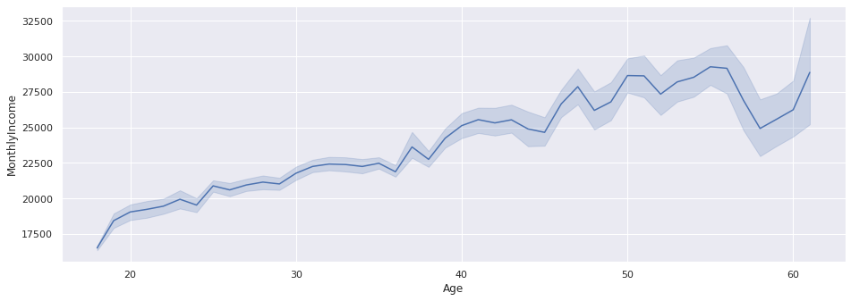

```python
fig, ax = plt.subplots()
fig.set_size_inches(15.7, 5.27)
ax = sns.lineplot(x=data['Age'], y=data['MonthlyIncome'])
```

## Observation between Passport and ProdTaken from the plot below

- As expected passport and travel go hand in hand. So passport holders are more likely to take a package.

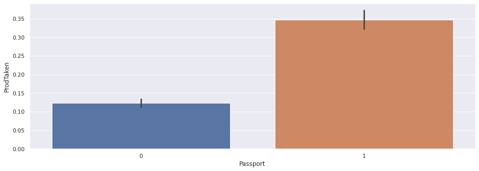

```python
fig, ax = plt.subplots()
fig.set_size_inches(15.7, 5.27)
ax = sns.barplot(x=data['Passport'], y=data['ProdTaken'])
```

## Observation between Passport and ProdTaken (between genders) from the plot below

- Male passport carriers are more likely to take the package than female passport carriers.
- Male who don't have passport are little more likely to take the package than female who doesn't have passport.

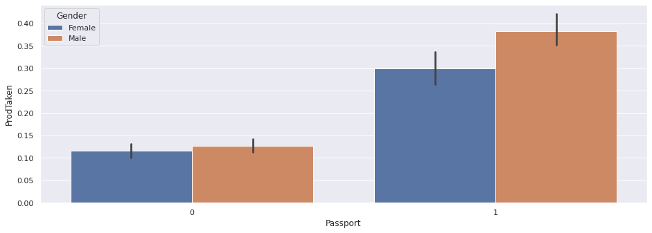

```python
fig, ax = plt.subplots()
fig.set_size_inches(15.7, 5.27)
ax = sns.barplot(x=data['Passport'], y=data['ProdTaken'],hue=data['Gender'])
```

## Observation between Gender and ProdTaken (if and if not own a car) from the plot below

- Females who don't own a car are little more likely to take the package than females who owns.
- Males who don't own a car are little more likely to take the package than males who owns.
- Males who don't own a car are more likely to take the package than the females who owns a car or not owns it.

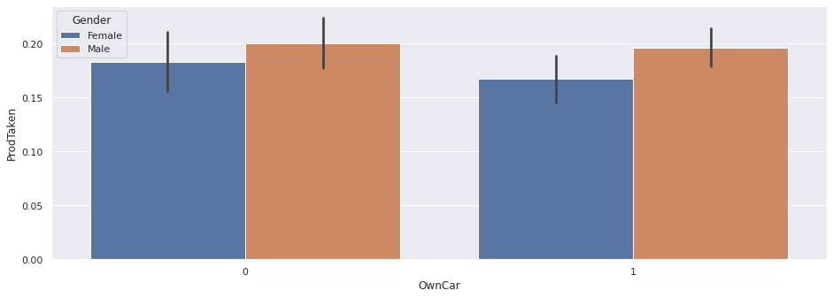

```python
fig, ax = plt.subplots()
fig.set_size_inches(15.7, 5.27)
ax = sns.barplot(x=data['OwnCar'], y=data['ProdTaken'],hue=data['Gender'])
```

## Observation between MonthlyIncome and Gender from the plot below

- The female section has some outliers, which needs to be looked into (in our feature engineering section)
- Other than that, the monthly income between male and female, does not seem to be that different.

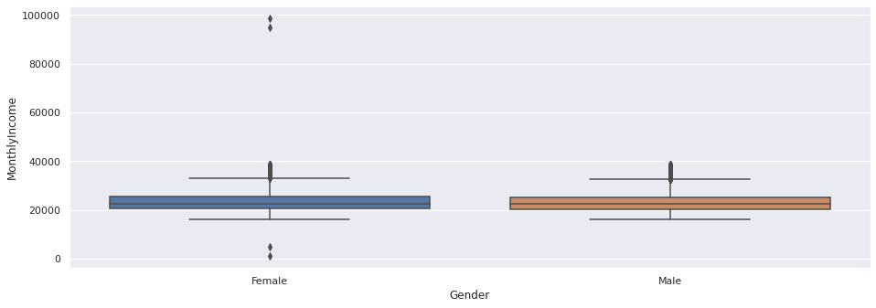

```python
fig, ax = plt.subplots()
fig.set_size_inches(15.7, 5.27)
ax = sns.boxplot(y=data['MonthlyIncome'], x=data['Gender'])
```

## Observation between MonthlyIncome and PreferredPropertyStar from the plot below

- There are some outliers (for the monthly income) for preferred property star 3 and 5
- Other than that, there does not seem to be strong relation between monthly income and preferred property star

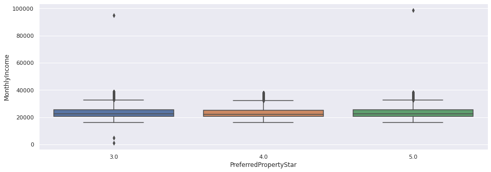

```python
fig, ax = plt.subplots()
fig.set_size_inches(15.7, 5.27)
ax = sns.boxplot(y=data['MonthlyIncome'], x=data['PreferredPropertyStar'])
```

## Observation between ProdTaken and NumberOfFollowups from the plot below

- With increased number of followups, the more the possbility to take a package.
- Hence definitely not be hesitant to keep reaching out to the customer.

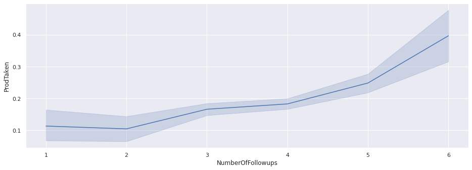

```python
fig, ax = plt.subplots()
fig.set_size_inches(15.7, 5.27)
ax = sns.lineplot(y=data['ProdTaken'], x=data['NumberOfFollowups'])
```

## Observation between ProdTaken and ProductPitched from the plot below

- Basic is the most purchased by the customer
- Standard is the second most purchased by the customer
- Super Deluxe is the least purchased by the customer
- Super Deluxe was pitched more than King, yet less purchased (think we should promote king more than super deluxe)

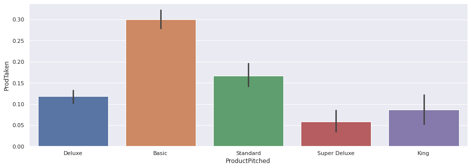

```python
fig, ax = plt.subplots()
fig.set_size_inches(15.7, 5.27)
ax = sns.barplot(y=data['ProdTaken'], x=data['ProductPitched'])
```

## Observation between ProdTaken and MaritalStatus from the plot below

- In male gender, Single customers are the most buyers of the package.
- In male gender, Unmarried customers are the second most buyers of the package.
- In Female gender, Single customers are the most buyers of the package.
- In Female gender, Unmarried customers are the second most buyers of the package.
- Divorced Male are most likely to buy the package than Female divorced customer.

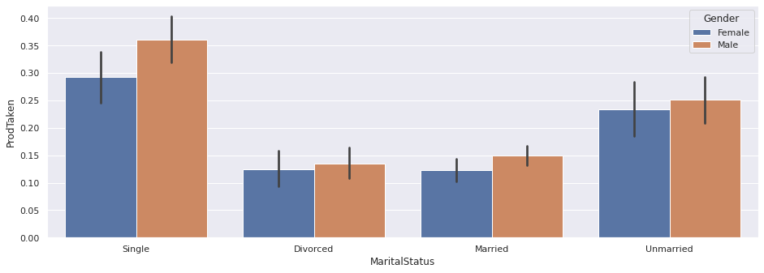

```python
fig, ax = plt.subplots()
fig.set_size_inches(15.7, 5.27)
ax = sns.barplot(y=data['ProdTaken'], x=data['MaritalStatus'],hue=data['Gender'])
```

## Observation between ProdTaken and Designation from the plot below

- Female and Male Executives are the most purchasers of the package.
- Also Female VPs are more likely to take the package than Male vps.

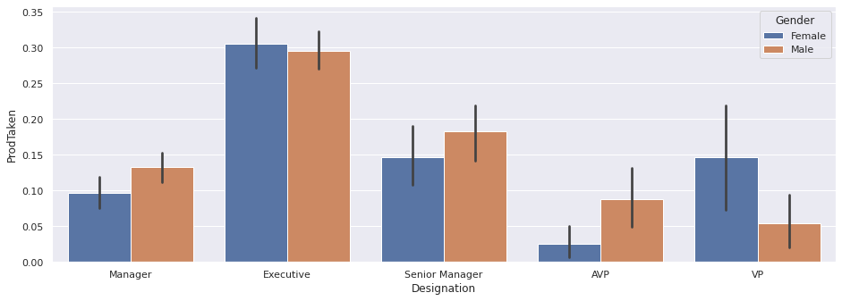

```python
fig, ax = plt.subplots()
fig.set_size_inches(15.7, 5.27)
ax = sns.barplot(y=data['ProdTaken'], x=data['Designation'],hue=data['Gender'])
```

## Observation between ProdTaken and Occupation from the plot below

- Freelancers are the most buyers of the package.
- Large business customers are the second most buyers of the package.
- Salaried and small business are some of the least buyers.

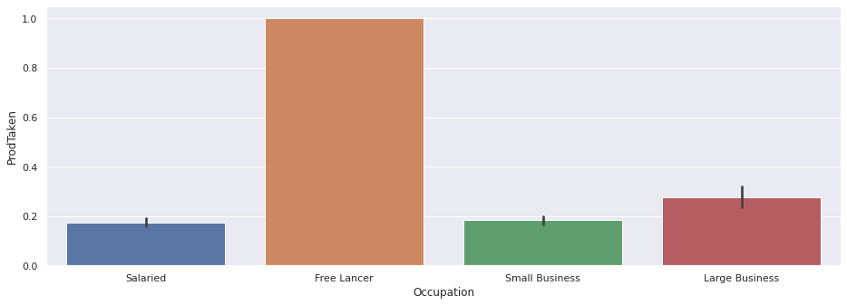

```python
fig, ax = plt.subplots()
fig.set_size_inches(15.7, 5.27)
ax = sns.barplot(y=data['ProdTaken'], x=data['Occupation'])
```

## Observation between ProdTaken and Occupation (considering CityTier) from the plot below

- Freelancers in city tier 1 are the most buyers of the package.
- Large business customers in city tier 2 are the most buyers of the package
- Salaried and small business in city tier 1 are some of the least buyers.
- city tier 3 (salaried and small business) are most likely to buy than city tier 1

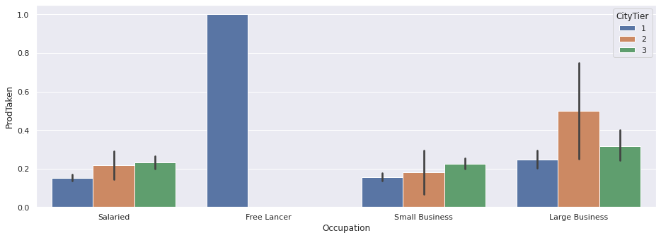

```python
fig, ax = plt.subplots()
fig.set_size_inches(15.7, 5.27)
ax = sns.barplot(y=data['ProdTaken'], x=data['Occupation'],hue=data["CityTier"])
```

## Observation between ProdTaken and TypeofContact

- Company invited folks are more likely to buy than self inquiry (so definitely worth it in reaching out)

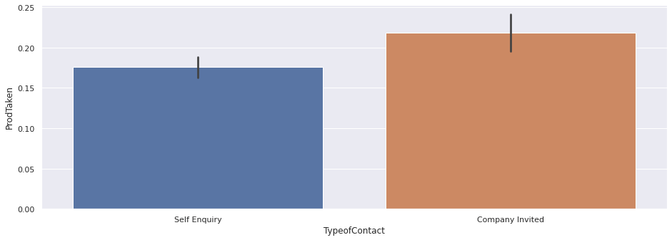

```python
fig, ax = plt.subplots()
fig.set_size_inches(15.7, 5.27)
ax = sns.barplot(y=data['ProdTaken'], x=data['TypeofContact'])
```

## Observation between ProdTaken and PitchSatisfactionScore

- Interestingly, score of 3 and 5 are good indictors of package being purchased.

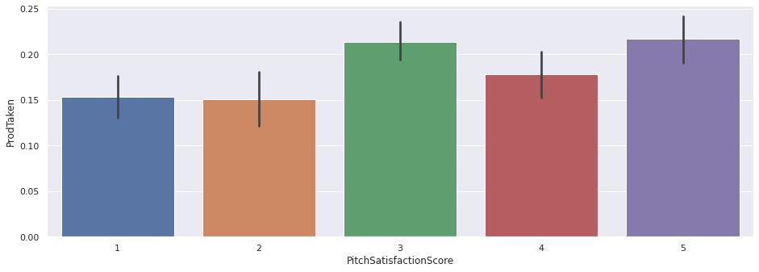

```python
fig, ax = plt.subplots()
fig.set_size_inches(15.7, 5.27)
ax = sns.barplot(y=data['ProdTaken'], x=data['PitchSatisfactionScore'])
```

## Observation between MaritalStatus and ProdTaken

- Single city tier 3 customers are most likely to buy the package than in city tier 1.
- Married city tier 2 customers are most likely to buy than other married customers in other city tiers.
- Unmarried city tier 3 customers are most likely to buy than unmarried city tier 1 customers.

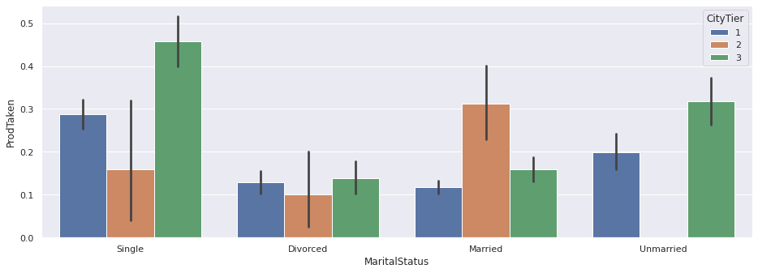

```python
fig, ax = plt.subplots()
fig.set_size_inches(15.7, 5.27)
ax = sns.barplot(y=data['ProdTaken'], x=data['MaritalStatus'],hue=data["CityTier"])
```

# Data Pre-processing

## Missing Value treatment

This was done before already for better EDA. Here is the link: Missing value treatment (to a previous cell)

## Data prep work - Fixing the Gender field

This was done before already for better EDA. Here is the link: Fixing_gender (to a previous cell)

## Data prep work - Dropping the NumberOfChildrenVisiting field

NumberOfChildrenVisiting is included within the NumberOfPersonVisiting field. Hence just removing the NumberOfChildrenVisiting field

```python
# dropping the NumberOfChildrenVisiting column
data.drop(columns="NumberOfChildrenVisiting",inplace=True)
```

```python
data.head()
```

|  | ProdTaken | Age | TypeofContact | CityTier | DurationOfPitch | Occupation | Gender | NumberOfPersonVisiting | NumberOfFollowups | ProductPitched | PreferredPropertyStar | MaritalStatus | NumberOfTrips | Passport | PitchSatisfactionScore | OwnCar | Designation | MonthlyIncome |
| --- | --- | --- | --- | --- | --- | --- | --- | --- | --- | --- | --- | --- | --- | --- | --- | --- | --- | --- |
| 0 | 1 | 41.0 | Self Enquiry | 3 | 6.0 | Salaried | Female | 3 | 3.0 | Deluxe | 3.0 | Single | 1.0 | 1 | 2 | 1 | Manager | 20993.0 |
| 1 | 0 | 49.0 | Company Invited | 1 | 14.0 | Salaried | Male | 3 | 4.0 | Deluxe | 4.0 | Divorced | 2.0 | 0 | 3 | 1 | Manager | 20130.0 |
| 2 | 1 | 37.0 | Self Enquiry | 1 | 8.0 | Free Lancer | Male | 3 | 4.0 | Basic | 3.0 | Single | 7.0 | 1 | 3 | 0 | Executive | 17090.0 |
| 3 | 0 | 33.0 | Company Invited | 1 | 9.0 | Salaried | Female | 2 | 3.0 | Basic | 3.0 | Divorced | 2.0 | 1 | 5 | 1 | Executive | 17909.0 |
| 4 | 0 | 36.0 | Self Enquiry | 1 | 8.0 | Small Business | Male | 2 | 3.0 | Basic | 4.0 | Divorced | 1.0 | 0 | 5 | 1 | Executive | 18468.0 |

## Data prep work - Dropping the PitchScore field

The pitch score does not give a strong signal, whether the product will be taken or not. For example, people who gave 3 have taken the package more than the people who have given 4. so it is good to drop it.

```python
# dropping the OwnCar column
data.drop(columns="PitchSatisfactionScore",inplace=True)
```

## Data prep work - Dropping the OwnCar field

The own car does not give a strong signal, whether the product will be taken or not. It is safe to drop that column

```python
# dropping the OwnCar column
data.drop(columns="OwnCar",inplace=True)
```

## Data prep work - Dropping the NumberOfPersonVisiting field

The number of person visiting does not give a strong signal, whether the product will be taken or not. It is safe to drop that column

```python
data.drop(columns="NumberOfPersonVisiting",inplace=True)
```

# Outlier treatment

## Check presence of outlier

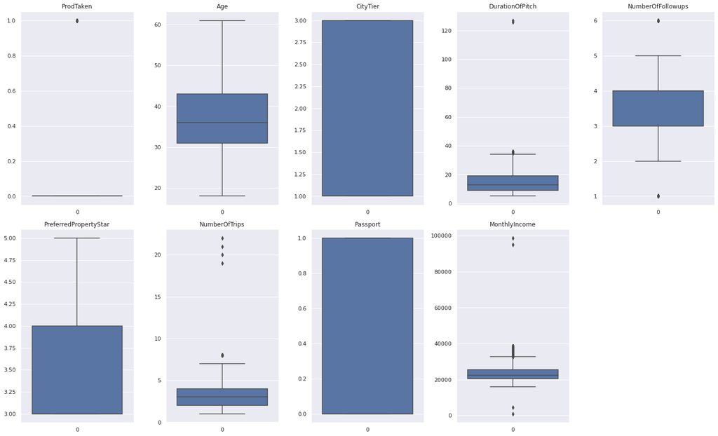

```python
numerical_col = data.select_dtypes(include=np.number).columns.tolist()
box_plot_num_columns(numerical_col)
```

The following fields will be treated for outliers:

- Monthly income (this is causing some skewness in the data and need to be treated)
- Number of trips: there are very very few customers with very high number of trips (this needs to be treated as well)
- Duration of pitch: It has an outlier which says the max duration of pitch is 127 (going by minutes). This does not make any sense and needs to be removed.

## Treating the outliers below

```python
numerical_col = ["MonthlyIncome","NumberOfTrips","DurationOfPitch"]
data = treat_all_outliers(data, numerical_col)
```

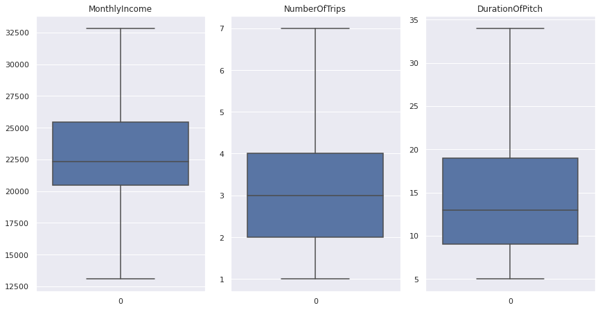

```python
# Now plot the results and see again
box_plot_num_columns(columns=numerical_col)
```

# Check for skewness in the data

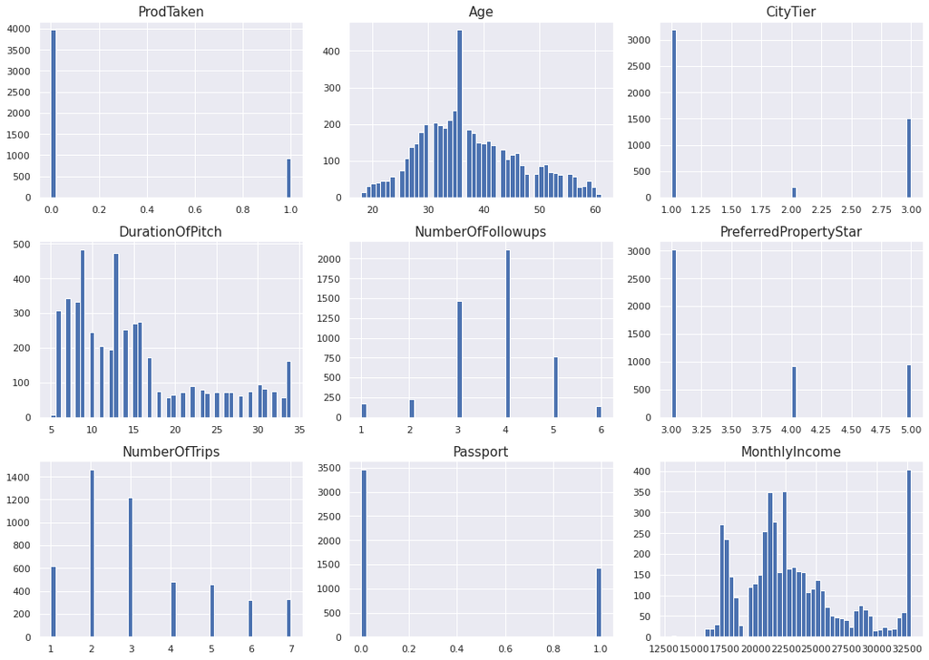

```python
# creating a list of numerical columns
num_cols = [
    num_col for num_col in data.select_dtypes(include=np.number).columns
]

plt.figure(figsize=(15, 35))

# then plot the numerical columns.
for i in range(len(num_cols)):
    plt.subplot(10, 3, i + 1)
    plt.hist(data[num_cols[i]], bins=50)
    plt.tight_layout()
    plt.title(num_cols[i], fontsize=15)

plt.show()
```

## Skewness in "DurationofPitch"

As we can see above for "DurationofPitch", it is skewed. All the other plots, look fine. So lets try to fix it.

# Apply log transformation only to "DurationofPitch"

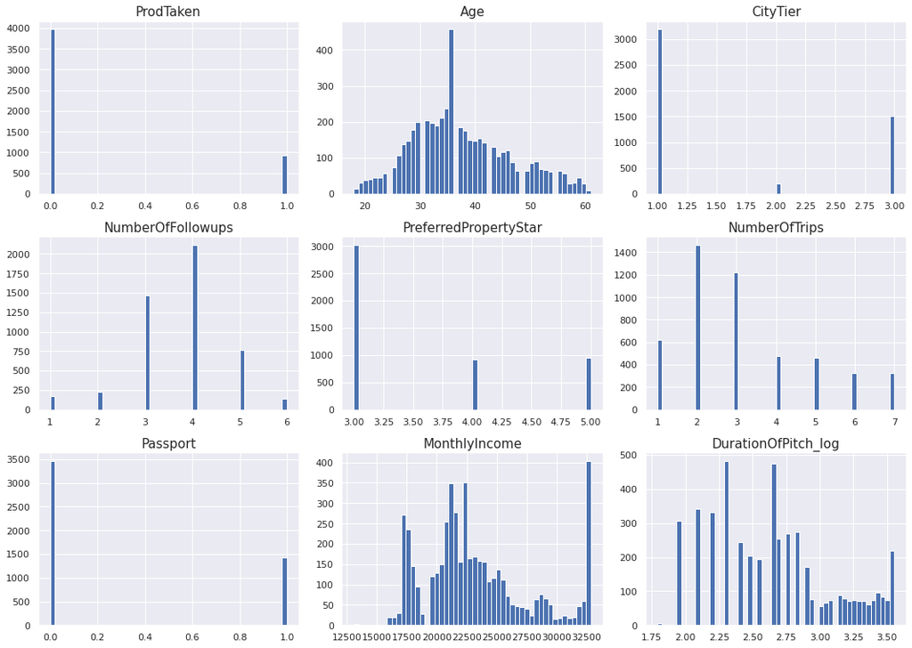

```python
data_skew_fixed = data.copy()
# these are less skewed and no need to apply log on it
num_cols.remove("ProdTaken")
num_cols.remove("Age")
num_cols.remove("CityTier")
num_cols.remove("NumberOfFollowups")
num_cols.remove("PreferredPropertyStar")
num_cols.remove("NumberOfTrips")
num_cols.remove("Passport")
num_cols.remove("MonthlyIncome")


# apply the log transform
for col in num_cols:
    data_skew_fixed[col + "_log"] = np.log(data_skew_fixed[col] + 1)


# drop the original numerical columns and use the log ones.
data_skew_fixed.drop(num_cols, axis=1, inplace=True)

# Creating a list of numerical columns with log transform applied.
num_cols = [
    num_col for num_col in data_skew_fixed.select_dtypes(include=np.number).columns
]

plt.figure(figsize=(15, 35))

for i in range(len(num_cols)):
    plt.subplot(10, 3, i + 1)
    plt.hist(data_skew_fixed[num_cols[i]], bins=50)
    plt.tight_layout()
    plt.title(num_cols[i], fontsize=15)

plt.show()
```

## Skewness in "DurationofPitch" after log transformation

As we can see above for "DurationofPitch_log" is better now (skew is less now) compared to before.

## Data prep work - hot encoding

```python
replaceStruct = {"Passport":{1:2,0:1}}
oneHotCols=["TypeofContact","Gender","MaritalStatus","Designation","ProductPitched","Occupation"]
```

```python
data_skew_fixed=data_skew_fixed.replace(replaceStruct)
data_skew_fixed=pd.get_dummies(data, columns=oneHotCols)
data_skew_fixed.head(10)
```

|  | ProdTaken | Age | CityTier | DurationOfPitch | NumberOfFollowups | PreferredPropertyStar | NumberOfTrips | Passport | MonthlyIncome | TypeofContact_Company Invited | ... | Designation_VP | ProductPitched_Basic | ProductPitched_Deluxe | ProductPitched_King | ProductPitched_Standard | ProductPitched_Super Deluxe | Occupation_Free Lancer | Occupation_Large Business | Occupation_Salaried | Occupation_Small Business |
| --- | --- | --- | --- | --- | --- | --- | --- | --- | --- | --- | --- | --- | --- | --- | --- | --- | --- | --- | --- | --- | --- |
| 0 | 1 | 41.0 | 3 | 6.0 | 3.0 | 3.0 | 1.0 | 1 | 20993.0 | 0 | ... | 0 | 0 | 1 | 0 | 0 | 0 | 0 | 0 | 1 | 0 |
| 1 | 0 | 49.0 | 1 | 14.0 | 4.0 | 4.0 | 2.0 | 0 | 20130.0 | 1 | ... | 0 | 0 | 1 | 0 | 0 | 0 | 0 | 0 | 1 | 0 |
| 2 | 1 | 37.0 | 1 | 8.0 | 4.0 | 3.0 | 7.0 | 1 | 17090.0 | 0 | ... | 0 | 1 | 0 | 0 | 0 | 0 | 1 | 0 | 0 | 0 |
| 3 | 0 | 33.0 | 1 | 9.0 | 3.0 | 3.0 | 2.0 | 1 | 17909.0 | 1 | ... | 0 | 1 | 0 | 0 | 0 | 0 | 0 | 0 | 1 | 0 |
| 4 | 0 | 36.0 | 1 | 8.0 | 3.0 | 4.0 | 1.0 | 0 | 18468.0 | 0 | ... | 0 | 1 | 0 | 0 | 0 | 0 | 0 | 0 | 0 | 1 |
| 5 | 0 | 32.0 | 1 | 8.0 | 3.0 | 3.0 | 1.0 | 0 | 18068.0 | 1 | ... | 0 | 1 | 0 | 0 | 0 | 0 | 0 | 0 | 1 | 0 |
| 6 | 0 | 59.0 | 1 | 9.0 | 2.0 | 5.0 | 5.0 | 1 | 17670.0 | 0 | ... | 0 | 1 | 0 | 0 | 0 | 0 | 0 | 0 | 0 | 1 |
| 7 | 0 | 30.0 | 1 | 30.0 | 3.0 | 3.0 | 2.0 | 0 | 17693.0 | 0 | ... | 0 | 1 | 0 | 0 | 0 | 0 | 0 | 0 | 1 | 0 |
| 8 | 0 | 38.0 | 1 | 29.0 | 4.0 | 3.0 | 1.0 | 0 | 24526.0 | 1 | ... | 0 | 0 | 0 | 0 | 1 | 0 | 0 | 0 | 1 | 0 |
| 9 | 0 | 36.0 | 1 | 33.0 | 3.0 | 3.0 | 7.0 | 0 | 20237.0 | 0 | ... | 0 | 0 | 1 | 0 | 0 | 0 | 0 | 0 | 0 | 1 |

10 rows × 31 columns

# Generating the training and the testing data

```python
X = data_skew_fixed.drop("ProdTaken" , axis=1)
y = data_skew_fixed.pop("ProdTaken")
```

```python
X_train, X_test, y_train, y_test = train_test_split(X,
                                                    y,
                                                    test_size=.30,
                                                    random_state=1,
                                                    stratify=y)
```

# which metric is right for model performance evaluation ?

I think it is a top priority for "Visit with us" to reach every customer who will take the product. It it a loss of business if they dont. Hence going by that, I think "Recall" is the score we need to keep our eye on.

Since lower recall means higher FN (meaning predicting a person as not taking the package, but they have). hence we need to keep our **recall** higher.

# Model building - Bagging

```python
#base_estimator for bagging classifier is a decision tree by default
bagging_estimator=BaggingClassifier(random_state=1)
bagging_estimator.fit(X_train,y_train)
```

```
BaggingClassifier(random_state=1)
```

## Model building - Bagging - performance on training and testing data

```python
print("Bagging classifier on training data")
print_model_performance_for_classification(model=bagging_estimator,
                                           features=X_train,
                                           target=y_train)
```

```
Bagging classifier on training data
Accuracy:0.9938614440222158
Recall:0.968944099378882
Precision: 0.9984
F1 score: 0.983451536643026
```

```python
print("Bagging classifier on testing data")
print_model_performance_for_classification(model=bagging_estimator,
                                           features=X_test,
                                           target=y_test)
```

```
Bagging classifier on testing data
Accuracy:0.9168370824812543
Recall:0.6376811594202898
Precision: 0.8888888888888888
F1 score: 0.7426160337552743
```

# Model building - Random forest classifier

```python
rf_estimator=RandomForestClassifier(random_state=1)
rf_estimator.fit(X_train,y_train)
```

```
RandomForestClassifier(random_state=1)
```

## Model building - Random forest classifier - performance on training and testing data

```python
print("Random forest classifier on training data")
print_model_performance_for_classification(model=rf_estimator,
                                           features=X_train,
                                           target=y_train)
```

```
Random forest classifier on training data
Accuracy:1.0
Recall:1.0
Precision: 1.0
F1 score: 1.0
```

```python
print("Random forest classifier on testing data")
print_model_performance_for_classification(model=rf_estimator,
                                           features=X_test,
                                           target=y_test)
```

```
Random forest classifier on testing data
Accuracy:0.9222903885480572
Recall:0.6521739130434783
Precision: 0.9090909090909091
F1 score: 0.759493670886076
```

# Model building - Decision Tree classifier

```python
dt_estimator=DecisionTreeClassifier(random_state=1)
dt_estimator.fit(X_train,y_train)
```

```
DecisionTreeClassifier(random_state=1)
```

## Model building - Decision Tree classifier - performance on training and testing data

```python
print("Decision tree classifier on training data")
print_model_performance_for_classification(model=dt_estimator,
                                           features=X_train,
                                           target=y_train)
```

```
Decision tree classifier on training data
Accuracy:1.0
Recall:1.0
Precision: 1.0
F1 score: 1.0
```

```python
print("Decision tree classifier on testing data")
print_model_performance_for_classification(model=dt_estimator,
                                           features=X_test,
                                           target=y_test)
```

```
Decision tree classifier on testing data
Accuracy:0.8868438991138378
Recall:0.717391304347826
Precision: 0.6923076923076923
F1 score: 0.7046263345195729
```

# Tunning the Bagging classifier

```python
bagging_estimator_pre_tuned = BaggingClassifier(random_state=1)
parameters = {
              'n_estimators' : [80,100],
             }
bagging_estimator_tuned =tune_model(model=bagging_estimator_pre_tuned,
                                    parameters=parameters,
                                    X_train=X_train,
                                    y_train=y_train)

print("Tuned bagging classifier on the training data")
print_model_performance_for_classification(model=bagging_estimator_tuned,
                                           features=X_train,
                                           target=y_train)

print("\nTuned bagging classifier on the testing data")
print_model_performance_for_classification(model=bagging_estimator_tuned,
                                           features=X_test,
                                           target=y_test)
```

```
Tuned bagging classifier on the training data
Accuracy:1.0
Recall:1.0
Precision: 1.0
F1 score: 1.0

Tuned bagging classifier on the testing data
Accuracy:0.9372869802317655
Recall:0.7282608695652174
Precision: 0.9220183486238532
F1 score: 0.8137651821862348
```

# Tunning the Random forest classifier

```python
rf_estimator_pre_tuned = RandomForestClassifier(random_state=1)
parameters = {
              "max_features": np.arange(0.4, 0.6, 0.1),
             }
rf_estimator_tuned =tune_model(model=rf_estimator_pre_tuned,
                               parameters=parameters,
                               X_train=X_train,
                               y_train=y_train)

print("Tuned random forst classifier on the training data")
print_model_performance_for_classification(model=rf_estimator_tuned,
                                           features=X_train,
                                           target=y_train)

print("\nTuned random forst classifier on the testing data")
print_model_performance_for_classification(model=rf_estimator_tuned,
                                           features=X_test,
                                           target=y_test)
```

```
Tuned random forst classifier on the training data
Accuracy:1.0
Recall:1.0
Precision: 1.0
F1 score: 1.0

Tuned random forst classifier on the testing data
Accuracy:0.9372869802317655
Recall:0.7210144927536232
Precision: 0.9299065420560748
F1 score: 0.8122448979591836
```

# Tunning the Decision tree classifier

```python
dt_estimator_pre_tuned=DecisionTreeClassifier(random_state=1)
parameters = {
              "max_features": np.arange(0.1, 0.9, 0.1),
              "max_depth": np.arange(1, 20, 1),
             }
dt_estimator_tuned =tune_model(model=dt_estimator_pre_tuned,
                               parameters=parameters,
                               X_train=X_train,
                               y_train=y_train)

print("Tuned decision tree classifier on the training data")
print_model_performance_for_classification(model=rf_estimator_tuned,
                                           features=X_train,
                                           target=y_train)

print("\nTuned decision tree classifier on the testing data")
print_model_performance_for_classification(model=rf_estimator_tuned,
                                           features=X_test,
                                           target=y_test)
```

[output not shown]

```python
# set the list of models
models = [bagging_estimator,
          bagging_estimator_tuned,
          rf_estimator,
          rf_estimator_tuned,
          dt_estimator,
          dt_estimator_tuned,]

acc_train = []
acc_test = []
recall_train = []
recall_test = []
precision_train = []
precision_test = []

# then iterate and get the scores for each model
for model in models:
    j = get_metrics_score(model,
                          X_train,
                          X_test,
                          y_train,
                          y_test)
    acc_train.append(np.round(j[0],2))
    acc_test.append(np.round(j[1],2))
    recall_train.append(np.round(j[2],2))
    recall_test.append(np.round(j[3],2))
    precision_train.append(np.round(j[4],2))
    precision_test.append(np.round(j[5],2))
```

```
[Text(0, 0, 'Bagging classifier default'),
```

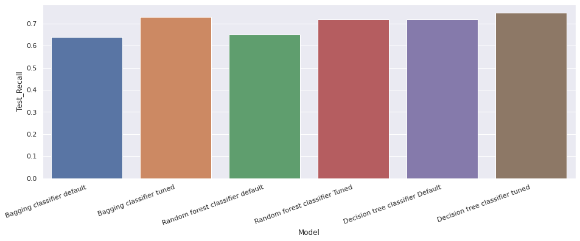

```python
model_score_table = pd.DataFrame({'Model':['Bagging classifier default',
                                          'Bagging classifier tuned',
                                          'Random forest classifier default',
                                          'Random forest classifier Tuned',
                                          'Decision tree classifier Default',
                                          'Decision tree classifier tuned',],
                                          'Train_Accuracy': acc_train,'Test_Accuracy': acc_test,
                                          'Train_Recall':recall_train,'Test_Recall':recall_test,
                                          'Train_Precision':precision_train,'Test_Precision':precision_test})
fig, ax = plt.subplots()
fig.set_size_inches(15.7, 5.27)
ax = sns.barplot(y=model_score_table['Test_Recall'], x=model_score_table['Model'])
ax.set_xticklabels(ax.get_xticklabels(), rotation=20, ha="right")
```

## Observations on model performance among Bagging classifier, random forst and decision tree (tuned and not tuned)

- All the tuned models have better recall score compared to pre tuned models
- Tuned decision tree classifier has the best recall score on the test set
- Default bagging classifier has the worst recall score on the test set
- Tuned bagging classifier recall score is much better than its default.
- Also in general, the metrics score are way better for training data compared to testing data for all the models, which shows overfitting.

## Model score table for Bagging classifier, random forst and decision tree (tuned and not tuned) on other metrics

```python
model_score_table
```

|  | Model | Train_Accuracy | Test_Accuracy | Train_Recall | Test_Recall | Train_Precision | Test_Precision |
| --- | --- | --- | --- | --- | --- | --- | --- |
| 0 | Bagging classifier default | 0.99 | 0.92 | 0.97 | 0.64 | 1.0 | 0.89 |
| 1 | Bagging classifier tuned | 1.00 | 0.94 | 1.00 | 0.73 | 1.0 | 0.92 |
| 2 | Random forest classifier default | 1.00 | 0.92 | 1.00 | 0.65 | 1.0 | 0.91 |
| 3 | Random forest classifier Tuned | 1.00 | 0.94 | 1.00 | 0.72 | 1.0 | 0.93 |
| 4 | Decision tree classifier Default | 1.00 | 0.89 | 1.00 | 0.72 | 1.0 | 0.69 |
| 5 | Decision tree classifier tuned | 1.00 | 0.90 | 1.00 | 0.75 | 1.0 | 0.71 |

# Model building - Adaboost classifier

```python
abc = AdaBoostClassifier(random_state=1)
abc.fit(X_train,y_train)
print("Adaboost classifier on the training data")
print_model_performance_for_classification(model=abc,
                                           features=X_train,
                                           target=y_train)

print("\nAdaboost classifier on the testing data")
print_model_performance_for_classification(model=abc,
                                           features=X_test,
                                           target=y_test)
```

```
Adaboost classifier on the training data
Accuracy:0.8500438468284127
Recall:0.3105590062111801
Precision: 0.7434944237918215
F1 score: 0.43811610076670315

Adaboost classifier on the testing data
Accuracy:0.8493524199045671
Recall:0.3188405797101449
Precision: 0.7272727272727273
F1 score: 0.4433249370277078
```

# Model building - Gradient boost classifier

```python
gbc = GradientBoostingClassifier(random_state=1)
gbc.fit(X_train,y_train)
print("Gradientboost classifier on the training data")
print_model_performance_for_classification(model=gbc,
                                           features=X_train,
                                           target=y_train)

print("\nGradientboost classifier on the testing data")
print_model_performance_for_classification(model=gbc,
                                           features=X_test,
                                           target=y_test)
```

```
Gradientboost classifier on the training data
Accuracy:0.8842443729903537
Recall:0.4472049689440994
Precision: 0.8780487804878049
F1 score: 0.5925925925925927

Gradientboost classifier on the testing data
Accuracy:0.8725289706884799
Recall:0.42391304347826086
Precision: 0.8068965517241379
F1 score: 0.5558194774346793
```

# Model building - XGB classifier

```python
xgb = XGBClassifier(random_state=1,eval_metric='logloss',use_label_encoder=False)
xgb.fit(X_train,y_train)

print("xgb classifier on the training data")
print_model_performance_for_classification(model=xgb,
                                           features=X_train,
                                           target=y_train)

print("\nxgb classifier on the testing data")
print_model_performance_for_classification(model=xgb,
                                           features=X_test,
                                           target=y_test)
```

```
xgb classifier on the training data
Accuracy:0.9988307512423268
Recall:0.9937888198757764
Precision: 1.0
F1 score: 0.9968847352024921

xgb classifier on the testing data
Accuracy:0.9202453987730062
Recall:0.6666666666666666
Precision: 0.8803827751196173
F1 score: 0.7587628865979382
```

# Model building - Stacking classifier

```python
estimators = [
    ("rf", AdaBoostClassifier(random_state=1)),
    ("svr", GradientBoostingClassifier(random_state=1)),
]

sc = StackingClassifier(estimators=estimators,
                   final_estimator=XGBClassifier(random_state=1,eval_metric='logloss',use_label_encoder=False))
sc.fit(X_train, y_train)

print("Stacking classifier on the training data")
print_model_performance_for_classification(model=sc,
                                           features=X_train,
                                           target=y_train)

print("\nStacking classifier on the testing data")
print_model_performance_for_classification(model=sc,
                                           features=X_test,
                                           target=y_test)
```

```
Stacking classifier on the training data
Accuracy:0.8716749488453669
Recall:0.5217391304347826
Precision: 0.7194860813704497
F1 score: 0.6048604860486049

Stacking classifier on the testing data
Accuracy:0.8595773687798227
Recall:0.463768115942029
Precision: 0.6881720430107527
F1 score: 0.5541125541125541
```

# Tunning the Adaboost classifier

```python
# Choose the type of classifier.
abc_pre_tune = AdaBoostClassifier(random_state=1)
# Grid of parameters to choose from add from article

parameters = {
    #Let's try different max_depth for base_estimator
    "base_estimator":[DecisionTreeClassifier(max_depth=depth, random_state=1) for depth in [20,30]],
    "n_estimators": [100],

}
abc_tuned =tune_model(model=abc_pre_tune,
                      parameters=parameters,
                      X_train=X_train,
                      y_train=y_train)

print("Tuned adaboost classifier on the training data")
print_model_performance_for_classification(model=abc_tuned,
                                           features=X_train,
                                           target=y_train)

print("\nTuned adaboost classifier on the testing data")
print_model_performance_for_classification(model=abc_tuned,
                                           features=X_test,
                                           target=y_test)
```

```
Tuned adaboost classifier on the training data
Accuracy:1.0
Recall:1.0
Precision: 1.0
F1 score: 1.0

Tuned adaboost classifier on the testing data
Accuracy:0.89093387866394
Recall:0.7246376811594203
Precision: 0.704225352112676
F1 score: 0.7142857142857142
```

# Tunning the Gradientboost classifier

```python
gbc_pre_tune = GradientBoostingClassifier(random_state=1)
parameters = {
    "n_estimators": [100,150],
    "subsample":[0.3,0.9,1],

}
gbc_tuned =tune_model(model=gbc_pre_tune,
                      parameters=parameters,
                      X_train=X_train,
                      y_train=y_train)


print("Tuned gradientboost classifier on the training data")
print_model_performance_for_classification(model=gbc_tuned,
                                           features=X_train,
                                           target=y_train)

print("\nTuned gradientboost classifier on the testing data")
print_model_performance_for_classification(model=gbc_tuned,
                                           features=X_test,
                                           target=y_test)
```

```
Tuned gradientboost classifier on the training data
Accuracy:0.9014907921660333
Recall:0.5263975155279503
Precision: 0.9137466307277629
F1 score: 0.6679802955665025

Tuned gradientboost classifier on the testing data
Accuracy:0.874573960463531
Recall:0.4420289855072464
Precision: 0.8026315789473685
F1 score: 0.5700934579439253
```

# Tunning the XGBoost classifier

```python
xgb_pre_tune = XGBClassifier(random_state=1,eval_metric='logloss',use_label_encoder=False)
parameters = {
    "n_estimators": np.arange(10,90,20),
    "scale_pos_weight":[0,1,2,5],
}
xgb_tuned =tune_model(model=xgb_pre_tune,
                      parameters=parameters,
                      X_train=X_train,
                      y_train=y_train)

print("Tuned xgboost classifier on the training data")
print_model_performance_for_classification(model=xgb_tuned,
                                           features=X_train,
                                           target=y_train)

print("\nTuned xgboost classifier on the testing data")
print_model_performance_for_classification(model=xgb_tuned,
                                           features=X_test,
                                           target=y_test)
```

```
Tuned xgboost classifier on the training data
Accuracy:0.9883075124232681
Recall:0.9984472049689441
Precision: 0.9428152492668622
F1 score: 0.9698340874811463

Tuned xgboost classifier on the testing data
Accuracy:0.9038854805725971
Recall:0.7971014492753623
Precision: 0.7213114754098361
F1 score: 0.7573149741824442
```

```python
# set the list of models
models = [abc,
          abc_tuned,
          gbc,
          gbc_tuned,
          xgb,
          xgb_tuned]

acc_train = []
acc_test = []
recall_train = []
recall_test = []
precision_train = []
precision_test = []

# then iterate and get the scores for each model
for model in models:
    j = get_metrics_score(model,
                          X_train,
                          X_test,
                          y_train,
                          y_test)
    acc_train.append(np.round(j[0],2))
    acc_test.append(np.round(j[1],2))
    recall_train.append(np.round(j[2],2))
    recall_test.append(np.round(j[3],2))
    precision_train.append(np.round(j[4],2))
    precision_test.append(np.round(j[5],2))
```

```python
model_score_table = pd.DataFrame({'Model':[
                                          'AdaBoost with default paramters',
                                          'AdaBoost Tuned',
                                          'Gradient Boosting with default parameters',
                                          'Gradient Boosting Tuned',
                                          'XGBoost with default parameters',
                                          'XGBoost Tuned'],
                                          'Train_Accuracy': acc_train,'Test_Accuracy': acc_test,
                                          'Train_Recall':recall_train,'Test_Recall':recall_test,
                                          'Train_Precision':precision_train,'Test_Precision':precision_test})
```

```
[Text(0, 0, 'AdaBoost with default paramters'),
```

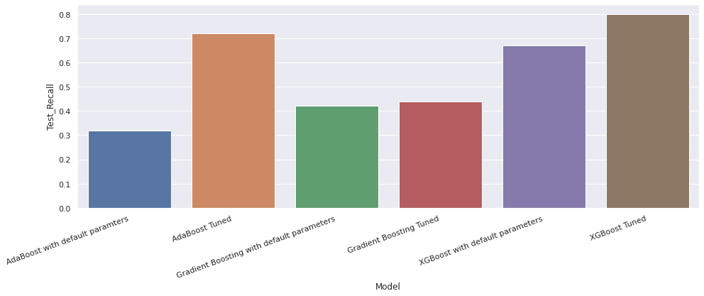

```python
fig, ax = plt.subplots()
fig.set_size_inches(15.7, 5.27)
ax = sns.barplot(y=model_score_table['Test_Recall'], x=model_score_table['Model'])
ax.set_xticklabels(ax.get_xticklabels(), rotation=20, ha="right")
```

## Observations on model performance among Adaboost, gradient boost and xgboost (tuned and not tuned)

```python
model_score_table
```

|  | Model | Train_Accuracy | Test_Accuracy | Train_Recall | Test_Recall | Train_Precision | Test_Precision |
| --- | --- | --- | --- | --- | --- | --- | --- |
| 0 | AdaBoost with default paramters | 0.85 | 0.85 | 0.31 | 0.32 | 0.74 | 0.73 |
| 1 | AdaBoost Tuned | 1.00 | 0.89 | 1.00 | 0.72 | 1.00 | 0.70 |
| 2 | Gradient Boosting with default parameters | 0.88 | 0.87 | 0.45 | 0.42 | 0.88 | 0.81 |
| 3 | Gradient Boosting Tuned | 0.90 | 0.87 | 0.53 | 0.44 | 0.91 | 0.80 |
| 4 | XGBoost with default parameters | 1.00 | 0.92 | 0.99 | 0.67 | 1.00 | 0.88 |
| 5 | XGBoost Tuned | 0.99 | 0.90 | 1.00 | 0.80 | 0.94 | 0.72 |

# Key takeaway for the business team

## Use the XGBosst Tuned model

- Please use XGBosst Tuned model to predict if a person will take the product or not. Only proceed if you get >30% score.
- In the mean time, I will continue on improving the model.

## So who should we call or not call ?

- People with passport are most likely to able to travel abroad, so for foriegn travel package of "Wellness Tourism Package" only approach if they have a passport first
- Also regarding passport, Male passport carriers are most likely to take the package compared to female passport holders. So prioritize in reaching out to Male customers first.
- If the customer does not have a passport, Men who don't have passport are little more likely to take the package than women who doesn't have passport. So prioritize men (who dont have passports) over women (who dont have passports)
- Also older people are less likely to take the package than younger ones, so please prioritize younger people compared to the older people.
- In male gender, Single customers and unmarried customers are the most buyers of the package. Hence when reaching out to men prioritize single and unmarried ones.
- In Female gender, Single customers and unmarried customers are the most buyers of the package. Hence when reaching out to women prioritize single and unmarried ones.
  - Divorced Men are most likely to buy the package than divorced women customer. Hence prioritize reaching out to divorced men over divorced women (for a better chance).
- Women and men Executives are the most purchasers of the package. Hence prioritize reaching out to them over other designations.
- Freelancers living in city tier 1 are very good target. This makes sense, as during freelancing it is easy to travel and work. So definitely reach out to all freelancing men/women in tier 1 cities. Also in genral reach out to all freelancers (as it is worthy shot)
- Large business customers in city tier 2 are a good target as well. As they will like to travel for pleasure or for their businees trips as well.
- Single people in city tier 3 customers are most likely to buy the package than in city tier 1. This makes sense as living in city tier 3 is mostly boring and they will want to explore. So definitely worth it to reach out to single people in city tier 3.
- Married city tier 2 customers are a good target too. Since they will like to explore more, since they might get bored (if living a long time) in city tier 2.
- Unmarried city tier 3 customers are most likely to buy than unmarried city tier 1 customers. This is obvious, being in suburban cities, they will definitely want to travel. so really worht it to reach out to them.

## Good behaviors on customer interaction and product side of things.

- With increased number of followups, the more the possbility to take a package. Hence definitely not be hesitant to keep reaching out to the customer. But not in a manner to come across as irritating.
- Basic is the most purchased package by the customer. Can we apply season discount on this and push little hard on this?. That will help selling more of this.
- Standard is the second most purchased by the customer. I would downplay it over Basic. If customer is not satisfied with Basic, then pitch the standard package.
- Super Deluxe was pitched more than King, yet less purchased. Please convey to Product team to revise super Deluxe (and later on spin it). But between super Deluxe and King, King is doing better. So king should be pitched instead of Super deluxe package.
- Data shows that company invited folks are more likely to buy than self inquiry. So definitey worth to keep reaching out to folks, than being reached out to.